# Assignment 1

Jiyun Won

3/14/2022

### Download required Packages

```r
if (! requireNamespace("biocManager", quietly = TRUE)){
  install.packages("BiocManager", repos = "http://cran.us.r-project.org")
}
```

```
##
##  /var/folders/_c/59gypyts1hn8xzqlpwyxvlw80000gn/T//Rtmpvab32x/downloaded_packages
```

```r
if (! requireNamespace("ComplexHeatmap", quietly = TRUE))
  BiocManager::install("ComplexHeatmap")
if (! requireNamespace("gprofiler2", quietly = TRUE))
  BiocManager::install("gprofiler2")
if (!requireNamespace("knitr", quietly = TRUE))
  BiocManager::install("knitr")
if (!requireNamespace("edgeR", quietly = TRUE))
  BiocManager::install("edgeR")
if (!requireNamespace("circlize", quietly = TRUE))
  BiocManager::install("circlize")
```

### library

```r
library(BiocManager)
```

```r
library(ComplexHeatmap)
library(gprofiler2)
library(knitr)
library(edgeR)
library(circlize)
library(Biobase)
```

### Load dataset

```r
nor_count <- read.table(file ="GSE84054_RLDNormalizedCount_12patientER.txt.gz", header = TRUE)
head(nor_count)
```

```
##     EnsemblGeneID   symbol     RHB037    RHB038    RHB041   RHB049    RHB050
## 1 ENSG00000000003   TSPAN6 10.5576953 10.292056  9.795420 9.281423 9.7227479
## 2 ENSG00000000005     TNMD  0.1611989  1.131630  2.465292 3.705893 0.2322995
## 3 ENSG00000000419     DPM1  9.6577465  9.693586 10.002489 9.092319 9.8432734
## 4 ENSG00000000457    SCYL3  7.9323206  7.914521  7.296315 7.532602 8.2553550
## 5 ENSG00000000460 C1orf112  7.0101568  6.670368  6.450546 6.478578 7.3319552
## 6 ENSG00000000938      FGR  4.5272595  5.656712  4.903025 7.052610 5.5277259
##      RHB052     RHB053    RHB350   RHB351    RHB353    RHB354    RHB355
## 1 9.6405959 11.1115388 10.533904 9.557097 9.9495396 10.401310 10.676409
## 2 0.6995199  0.7834846  1.258340 3.689829 0.3586667 11.176772  1.477047
## 3 9.3802693  9.8649627 10.053229 9.673415 9.1995151  9.299364  9.168183
## 4 7.6416368  7.7721158  7.958315 7.410217 8.5471767  7.931725  8.824975
## 5 6.3441867  6.5230015  7.048731 6.414059 7.1841034  6.589256  7.298871
## 6 5.3226292  5.5501276  5.324976 6.380313 5.0995456  5.587664  5.054077
##       RHB031    RHB032     RHB035    RHB043     RHB044     RHB046     RHB047
## 1 10.8015101 9.5848037 10.7914638 10.327016 10.0293444 10.5998931 11.4348263
## 2  0.2534048 0.1603047  0.1631237  0.203263  0.2410879  0.1983888  0.2055052
## 3 10.8872179 9.7078275 10.2774692 10.379846 11.0054711 10.7382149 10.5656841
## 4  7.8711915 8.1838827  7.5354863  6.954218  7.9472106  7.4565151  7.9195755
## 5  7.7503488 6.6327611  6.0137945  7.363981  6.8734879  7.2345023  6.1905883
## 6  3.0762339 4.0221040  1.0517396  4.384931  1.2507656  1.1451353  1.1632556
##       RHB344     RHB345    RHB347    RHB348    RHB349
## 1  9.4882301 10.7921365 8.5369392 9.5068566 9.9015459
## 2  0.1695964  0.2262067 0.1857955 0.1460338 0.1359234
## 3 10.1590535 10.6723379 9.0185132 9.3971392 8.9464301
## 4  7.5370234  7.7042383 7.7295091 6.9592613 8.4369697
## 5  6.6647781  6.2239584 6.0451091 5.8592912 5.4709587
## 6  1.0693681  1.2147589 1.1125015 1.0040117 0.9748992
```

### Differential Expression Analysis

## Model Design

Define your model design to be used to calculate differential expression - revisit your MDS plot from Assignment #1 to demonstrate your choice of factors in your model.

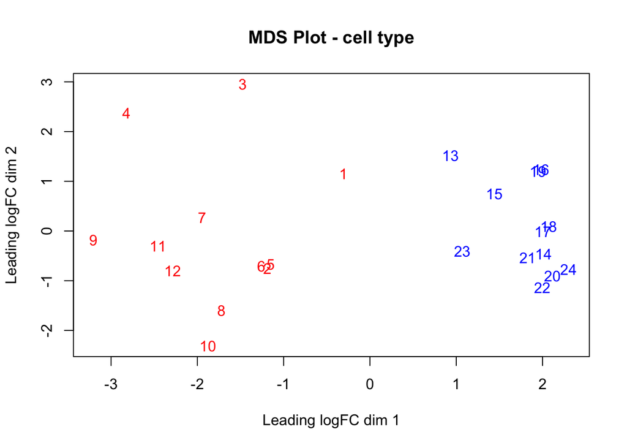

```r
### From a1
dt_type <- data.frame("Type"=1:24)
for (type1 in 1:12){
  dt_type$Type[type1] = "Primary Tumour"
}
for (type2 in 13:24){
  dt_type$Type[type2] = "Sphere"
}
rownames(dt_type) <- colnames(exp)[2:25]
###

type_map <- nor_count[,3:ncol(nor_count)]
rownames(type_map) <- nor_count$EnsemblGeneID
colnames(type_map) <- rownames(dt_type)

plotMDS(type_map, labels = rownames(dt_type),
        col = c("red", "blue")[factor(dt_type$Type)],
        main = "MDS Plot - cell type")
```

```r
modelDesign <- model.matrix(~ dt_type$Type)
head(modelDesign)
```

```
##   (Intercept) dt_type$TypeSphere
## 1           1                  0
## 2           1                  0
## 3           1                  0
## 4           1                  0
## 5           1                  0
## 6           1                  0
```

## Calculate p-values for each of the genes

Calculate p-values for each of the genes in your expression set. How many genes were significantly deferentially expressed? What thresholds did you use and why?

```r
expressionMatrix <- as.matrix(nor_count[, 3:ncol(nor_count)])
rownames(expressionMatrix) <- nor_count$EnsemblGeneID
colnames(expressionMatrix) <- colnames(nor_count)[3:ncol(nor_count)]
minimalSet <- ExpressionSet(assayData = expressionMatrix)
```

```r
fit <- lmFit(minimalSet, modelDesign)
#Apply empirical Bayes to compute differential expression
fit2 <- eBayes(fit, trend = TRUE) # trend=TRUE specific to RNA-seq data
```

```r
topfit <- topTable(fit2, coef = ncol(modelDesign),
                   adjust.method = "BH",
                   number = nrow(expressionMatrix))
# merge hgnc names to topfit table
output_hits <- merge(nor_count[,1:2], topfit, by.y = 0, by.x = 1, all.y = TRUE)

# sort by p-value
output_hits <- output_hits[order(output_hits$P.Value), ]
head(output_hits)
```

```
##         EnsemblGeneID  symbol     logFC  AveExpr         t      P.Value
## 3653  ENSG00000110077  MS4A6A -6.511737 6.480698 -19.73081 1.291322e-17
## 6523  ENSG00000133574  GIMAP4 -6.271284 5.437724 -19.53150 1.671109e-17
## 13736 ENSG00000179144  GIMAP7 -6.272167 5.563199 -18.32402 8.382470e-17
## 4516  ENSG00000116824     CD2 -5.795112 4.349120 -17.36626 3.218093e-16
## 5533  ENSG00000125810    CD93 -5.820752 4.823705 -17.11921 4.599499e-16
## 7209  ENSG00000137491 SLCO2B1 -5.193135 4.711880 -16.15249 1.941591e-15
##          adj.P.Val        B
## 3653  1.787669e-13 29.84527
## 6523  1.787669e-13 29.60820
## 13736 5.978098e-13 28.11465
## 4516  1.721277e-12 26.85560
## 5533  1.968126e-12 26.51944
## 7209  6.923389e-12 25.15657
```

## How many gene pass the threshold p-value<0.05

```r
length(which(output_hits$P.Value < 0.05)) #10071
```

```
## [1] 10071
```

## How many genes pass correction

```r
length(which(output_hits$adj.P.Val < 0.05)) #8016
```

```
## [1] 8016
```

## Differential expression calculation (edgeR)

EdgeR uses negative binomial distribution to model gene counts.

```r
### From a1
if (!file.exists("GSE84054_Rawcount_12patientER.txt.gz")){
  GSE84054 <- GEOquery::getGEOSuppFiles('GSE84054')
}
```

```
## Setting options('download.file.method.GEOquery'='auto')
```

```
## Setting options('GEOquery.inmemory.gpl'=FALSE)
```

```r
fnames = rownames(GSE84054)
exp <- read.delim(fnames[2], header=TRUE, check.names = FALSE)
cpms = edgeR::cpm(exp[, 2:25])
keep = rowSums(cpms > 1) >= 3 # Dataset of 3 samples per group
filtered_exp <- exp[keep,]
mart <- biomaRt::useMart("ensembl", dataset = "hsapiens_gene_ensembl")
map_exp <- biomaRt::getBM(filters = "ensembl_gene_id", attributes = c("hgnc_symbol", "ensembl_gene_id"), values = filtered_exp[1], mart = mart)
copy_filter <- filtered_exp
copy_filter <- merge(map_exp, copy_filter, by.x = 2, by.y = 1, all.y = TRUE)
###

mat <- as.matrix(copy_filter[,3:26])
rownames(mat) <- copy_filter$ensembl_gene_id
d = edgeR::DGEList(counts = mat, group = dt_type$Type)
# estimate Dispersion
d <- estimateDisp(d, modelDesign)
```

## Estimate Dispersion (plot BCV)

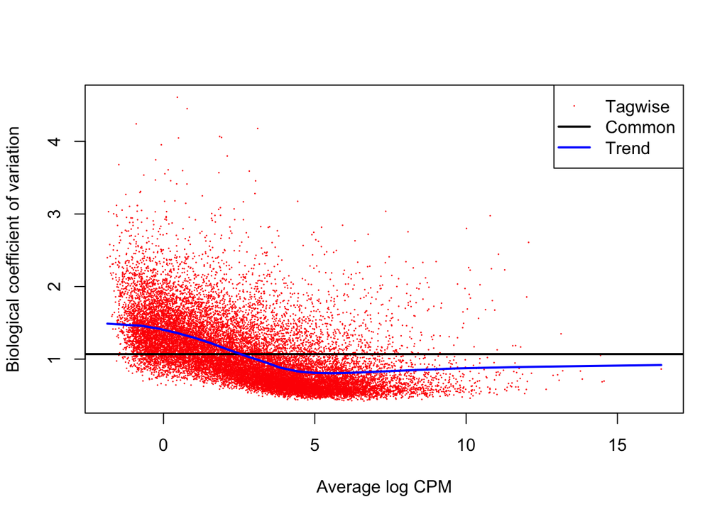

```r
# red dots : each gene
# blue line : trend
plotBCV(d, col.common = "black", col.tagwise = "red")
```

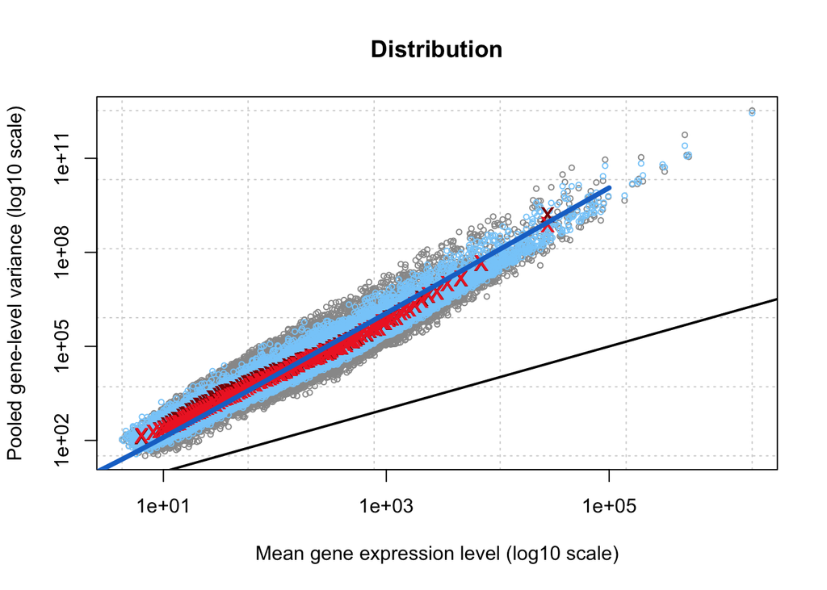

```r
# binomial distribution
plotMeanVar(d, show.raw.vars = TRUE,
            show.tagwise.vars = TRUE,
            show.ave.raw.vars = TRUE,
            NBline = TRUE,
            show.binned.common.disp.vars = TRUE,
            main = "Distribution")
```

## Calculate differential expression using Quasi liklihood model.

Quasi liklihood : used for complicated models and highly recommended for bulk RNASeq experiments.

```r
fit <- edgeR::glmQLFit(d, modelDesign)
qlf.pos_vs_neg <- edgeR::glmQLFTest(fit, coef = 'dt_type$TypeSphere')
head(qlf.pos_vs_neg)
```

[output not shown]

[output cut: 91 more lines]

```
## ENSG00000000003  0.03500217 6.036774  0.007727913 9.305912e-01
## ENSG00000000419  0.73064829 5.712271  4.536961562 4.233188e-02
## ENSG00000000457 -0.31517746 3.594160  0.874353891 3.579526e-01
## ENSG00000000460 -0.29825555 2.484793  0.594870312 4.471681e-01
## ENSG00000000938 -4.42642317 1.337520 17.013091531 3.126372e-04
## ENSG00000000971 -5.68374650 4.960519 25.107247559 2.876932e-05
##
## $comparison
## [1] "dt_type$TypeSphere"
##
## $df.test
## [1] 1 1 1 1 1 1
##
## $df.total
## [1] 27.29418 27.29418 27.29418 27.29418 27.29418 27.29418
```

```r
#get all the results
qlf_output_hits <- topTags(qlf.pos_vs_neg, sort.by = "PValue", n = nrow(nor_count))
```

## How many gene pass the threshold p-value<0.05

```r
length(which(qlf_output_hits$table$PValue < 0.05)) #7360
```

```
## [1] 7360
```

## How many genes pass correction

```r
length(which(qlf_output_hits$table$FDR < 0.05)) #4846
```

```
## [1] 4846
```

## How many genes are up regulated

```r
length(which(qlf_output_hits$table$PValue < 0.05 & qlf_output_hits$table$logFC > 0))
```

```
## [1] 1886
```

```r
# 1886
```